# RNASeq

Pierre-Yves Dupont

## Introduction

This is a test of the new tuxedo pipeline as described in [*Transcript-level expression analysis of RNA-seq experiments with HISAT, StringTie and Ballgown*](https://www.nature.com/nprot/journal/v11/n9/pdf/nprot.2016.095.pdf) (Pertea et al., Nature Protocol, Aug. 2016). The data for this can be downloaded from: this site. In the new *tuxedo* pipeline, the mapper *bowtie2* is replaced by *HiSAT2*. *StringTie* is then used to merge the files from *HiSAT2* and computer the coverage per gene (previously done with *cufflinks*). Finally *BallGown* computes the differentially expressed genes (as *cufflinks* used to).

## HiSAT2

*HiSAT2* is a spliced (or gapped) mapper. It is used for RNAseq mapping as the gene sequences may contain introns converted into gaps while aligning the RNAseq reads. HiSAT works on indexed reference files. To build this index, use:

```bash
hisat2-build reference output_dir
```

Many reference files can be used. They must be separated by commas on the command line. The indexes have already been built in the downloaded dataset. It is possible to provide the splicing sites (*ss*) and exons in the command line. They can be extracted from a *gtf* file giving information about genes and exons boundaries using tools provided with *HiSAT2*.

```bash
extract_splice_sites.py chrX_data/genes/chrX.gtf > chrX.ss
extract_exons.py chrX_data/genes/chrX.gtf > chrX.exon

hisat2-build --ss chrX.ss --exon chrX.exon chrX_data/genome/chrX.fa chrX_tran
```

Both *–ss* and *–exon* are optional arguments. This *hisat2-build* command took about 6min on the example dataset.

Here are all the HiSAT commands to map the reads from the 12 samples onto the indexed reference:

```bash
hisat2 -p 2 --dta -x chrX_data/indexes/chrX_tran -1 chrX_data/samples/ERR188044_chrX_1.fastq.gz -2 chrX_data/samples/ERR188044_chrX_2.fastq.gz -S ERR188044_chrX.sam --time
hisat2 -p 2 --dta -x chrX_data/indexes/chrX_tran -1 chrX_data/samples/ERR188104_chrX_1.fastq.gz -2 chrX_data/samples/ERR188104_chrX_2.fastq.gz -S ERR188104_chrX.sam --time
hisat2 -p 2 --dta -x chrX_data/indexes/chrX_tran -1 chrX_data/samples/ERR188234_chrX_1.fastq.gz -2 chrX_data/samples/ERR188234_chrX_2.fastq.gz -S ERR188234_chrX.sam --time
hisat2 -p 2 --dta -x chrX_data/indexes/chrX_tran -1 chrX_data/samples/ERR188245_chrX_1.fastq.gz -2 chrX_data/samples/ERR188245_chrX_2.fastq.gz -S ERR188245_chrX.sam --time
hisat2 -p 2 --dta -x chrX_data/indexes/chrX_tran -1 chrX_data/samples/ERR188257_chrX_1.fastq.gz -2 chrX_data/samples/ERR188257_chrX_2.fastq.gz -S ERR188257_chrX.sam --time
hisat2 -p 2 --dta -x chrX_data/indexes/chrX_tran -1 chrX_data/samples/ERR188273_chrX_1.fastq.gz -2 chrX_data/samples/ERR188273_chrX_2.fastq.gz -S ERR188273_chrX.sam --time
hisat2 -p 2 --dta -x chrX_data/indexes/chrX_tran -1 chrX_data/samples/ERR188337_chrX_1.fastq.gz -2 chrX_data/samples/ERR188337_chrX_2.fastq.gz -S ERR188337_chrX.sam --time
hisat2 -p 2 --dta -x chrX_data/indexes/chrX_tran -1 chrX_data/samples/ERR188383_chrX_1.fastq.gz -2 chrX_data/samples/ERR188383_chrX_2.fastq.gz -S ERR188383_chrX.sam --time
hisat2 -p 2 --dta -x chrX_data/indexes/chrX_tran -1 chrX_data/samples/ERR188401_chrX_1.fastq.gz -2 chrX_data/samples/ERR188401_chrX_2.fastq.gz -S ERR188401_chrX.sam --time
hisat2 -p 2 --dta -x chrX_data/indexes/chrX_tran -1 chrX_data/samples/ERR188428_chrX_1.fastq.gz -2 chrX_data/samples/ERR188428_chrX_2.fastq.gz -S ERR188428_chrX.sam --time
hisat2 -p 2 --dta -x chrX_data/indexes/chrX_tran -1 chrX_data/samples/ERR188454_chrX_1.fastq.gz -2 chrX_data/samples/ERR188454_chrX_2.fastq.gz -S ERR188454_chrX.sam --time
hisat2 -p 2 --dta -x chrX_data/indexes/chrX_tran -1 chrX_data/samples/ERR204916_chrX_1.fastq.gz -2 chrX_data/samples/ERR204916_chrX_2.fastq.gz -S ERR204916_chrX.sam --time
```

The mapping is fairly fast. Each command takes less than a minute. The generated files need then to be sorted and converted to smaller *bam* files. This is done using *smatools*.

```bash
samtools sort -@ 2 -o ERR188044_chrX.bam ERR188044_chrX.sam
samtools sort -@ 2 -o ERR188104_chrX.bam ERR188104_chrX.sam
samtools sort -@ 2 -o ERR188234_chrX.bam ERR188234_chrX.sam
samtools sort -@ 2 -o ERR188245_chrX.bam ERR188245_chrX.sam
samtools sort -@ 2 -o ERR188257_chrX.bam ERR188257_chrX.sam
samtools sort -@ 2 -o ERR188273_chrX.bam ERR188273_chrX.sam
samtools sort -@ 2 -o ERR188337_chrX.bam ERR188337_chrX.sam
samtools sort -@ 2 -o ERR188383_chrX.bam ERR188383_chrX.sam
samtools sort -@ 2 -o ERR188401_chrX.bam ERR188401_chrX.sam
samtools sort -@ 2 -o ERR188428_chrX.bam ERR188428_chrX.sam
samtools sort -@ 2 -o ERR188454_chrX.bam ERR188454_chrX.sam
samtools sort -@ 2 -o ERR204916_chrX.bam ERR204916_chrX.sam
```

This will generate 12 *bam* files (binary *sam* files) which are compressed, and here sorted, versions of the original *sam* files. The *sam* files can be removed

```bash
rm -f ERR*_chrX.sam
```

## StringTie

*StringTie* assembles RNAseq alignments from HiSat into potential transcripts. It can use a *gtf* file as a guide for the assembly.

```bash
stringtie -p 2 -G chrX_data/genes/chrX.gtf -o ERR188044_chrX.gtf -l ERR188044 ERR188044_chrX.bam
stringtie -p 2 -G chrX_data/genes/chrX.gtf -o ERR188104_chrX.gtf -l ERR188104 ERR188104_chrX.bam
stringtie -p 2 -G chrX_data/genes/chrX.gtf -o ERR188234_chrX.gtf -l ERR188234 ERR188234_chrX.bam
stringtie -p 2 -G chrX_data/genes/chrX.gtf -o ERR188245_chrX.gtf -l ERR188245 ERR188245_chrX.bam
stringtie -p 2 -G chrX_data/genes/chrX.gtf -o ERR188257_chrX.gtf -l ERR188257 ERR188257_chrX.bam
stringtie -p 2 -G chrX_data/genes/chrX.gtf -o ERR188273_chrX.gtf -l ERR188273 ERR188273_chrX.bam
stringtie -p 2 -G chrX_data/genes/chrX.gtf -o ERR188337_chrX.gtf -l ERR188337 ERR188337_chrX.bam
stringtie -p 2 -G chrX_data/genes/chrX.gtf -o ERR188383_chrX.gtf -l ERR188383 ERR188383_chrX.bam
stringtie -p 2 -G chrX_data/genes/chrX.gtf -o ERR188401_chrX.gtf -l ERR188401 ERR188401_chrX.bam
stringtie -p 2 -G chrX_data/genes/chrX.gtf -o ERR188428_chrX.gtf -l ERR188428 ERR188428_chrX.bam
stringtie -p 2 -G chrX_data/genes/chrX.gtf -o ERR188454_chrX.gtf -l ERR188454 ERR188454_chrX.bam
stringtie -p 2 -G chrX_data/genes/chrX.gtf -o ERR204916_chrX.gtf -l ERR204916 ERR204916_chrX.bam
```

On the example dataset, stringtie takes about 10s for each samples. It outputs new *gtf* files containing the coordinates of the rebuilt transcripts. All the *StringTie* results need to be merged into one unique transcript coordinate file. For this a list of the atomic *gtf* files need to be built first.

```bash
ls ERR*chrX.gtf > merge_list.txt
```

Now the files can be merged.

```bash
stringtie --merge -p 2 -G chrX_data/genes/chrX.gtf -o stringtie_merged.gtf merge_list.txt
```

This will generate an unique *gtf* file called *stringtie_merged.gtf*. Some extra information can be obtained using the *gffcompare* command fromt the *gffutilities* package. This step is optional.

```bash
gffcompare -r chrX_data/genes/chrX.gtf -G -o merged stringtie_merged.gtf
```

This will create few new files:

- merged.stats: containing information about the new/missed introns, exons and loci
- merged.annotated.gtf: a *gtf* files with information about each transcript provided in the field *class_code*. The *class_codes* are provided in table 1.
- merged.loci
- merged.stringtie_merged.gtf.refmap
- merged.stringtie_merged.gtf.tmap
- merged.tracking

**Table 1**

| Code | Description |
| --- | --- |
| = | Predicted transcript has exactly the same introns as the reference transcript |
| c | Predicted transcript is contained within the reference transcript |
| j | Predicted transcript is a potential novel isoform that shares at least one splice junction with a reference transcript |
| e | Predicted single-exon transcript overlaps a reference exon plus at least 10 bp of a reference intron, indicating a possible pre-mRNA fragment |
| i | Predicted transcript falls entirely within a reference intron |
| o | Exon of predicted transcript overlaps a reference transcript |
| p | Predicted transcript lies within 2 kb of a reference transcript (possible polymerase run-on fragment) |
| r | Predicted transcript has >50% of its bases overlapping a soft-masked (repetitive) reference sequence |
| u | Predicted transcript is intergenic in comparison with known reference transcripts |
| x | Exon of predicted transcript overlaps reference but lies on the opposite strand |
| s | Intron of predicted transcript overlaps a reference intron on the opposite strand |

## Compute transcript abundances and counts tables

This is also done using *StringTie*, but with different options.

```bash
stringtie -e -B -p 2 -G stringtie_merged.gtf -o ballgown/ERR188044/ERR188044_chrX.gtf ERR188044_chrX.bam
stringtie -e -B -p 2 -G stringtie_merged.gtf -o ballgown/ERR188104/ERR188104_chrX.gtf ERR188104_chrX.bam
stringtie -e -B -p 2 -G stringtie_merged.gtf -o ballgown/ERR188234/ERR188234_chrX.gtf ERR188234_chrX.bam
stringtie -e -B -p 2 -G stringtie_merged.gtf -o ballgown/ERR188245/ERR188245_chrX.gtf ERR188245_chrX.bam
stringtie -e -B -p 2 -G stringtie_merged.gtf -o ballgown/ERR188257/ERR188257_chrX.gtf ERR188257_chrX.bam
stringtie -e -B -p 2 -G stringtie_merged.gtf -o ballgown/ERR188273/ERR188273_chrX.gtf ERR188273_chrX.bam
stringtie -e -B -p 2 -G stringtie_merged.gtf -o ballgown/ERR188337/ERR188337_chrX.gtf ERR188337_chrX.bam
stringtie -e -B -p 2 -G stringtie_merged.gtf -o ballgown/ERR188383/ERR188383_chrX.gtf ERR188383_chrX.bam
stringtie -e -B -p 2 -G stringtie_merged.gtf -o ballgown/ERR188401/ERR188401_chrX.gtf ERR188401_chrX.bam
stringtie -e -B -p 2 -G stringtie_merged.gtf -o ballgown/ERR188428/ERR188428_chrX.gtf ERR188428_chrX.bam
stringtie -e -B -p 2 -G stringtie_merged.gtf -o ballgown/ERR188454/ERR188454_chrX.gtf ERR188454_chrX.bam
stringtie -e -B -p 2 -G stringtie_merged.gtf -o ballgown/ERR204916/ERR204916_chrX.gtf ERR204916_chrX.bam
```

## Differentially expressed genes (DEG) computation

The DEG computation is done using *ballgown*. The installation of *ballgown* can be done through *bioconductor*. The following commands are R commands that need to be launched in a R console (or in RStudio), unless specified otherwise.

```r
source("https://bioconductor.org/biocLite.R")
biocLite("ballgown")
```

It is also recommended to install the following libraries: * *RSkittleBrewer* * *genefilter* * *dplyr* * *devtools*

```r
install.packages(c("dplyr","devtools"))
devtools::install_github('alyssafrazee/RSkittleBrewer')

#source("https://bioconductor.org/biocLite.R")
biocLite("genefilter")
```

The libraries to load are:

```r
library(ballgown)
library(RSkittleBrewer)
library(genefilter)
library(dplyr)
library(devtools)
```

On Ubuntu 16.04, the following libraries are mandatory to install *devtools*:

```bash
# In a terminal
sudo apt install build-essential libcurl4-gnutls-dev libxml2-dev libssl-dev
```

The phenotype data (aka the samples information) need first to be loaded.

```r
#setwd("RNAseq_protocol")
pheno_data <- read.csv("chrX_data/geuvadis_phenodata.csv")
```

Here is the content of the table:

| ids | sex | population |
| --- | --- | --- |
| ERR188044 | male | YRI |
| ERR188104 | male | YRI |
| ERR188234 | female | YRI |
| ERR188245 | female | GBR |
| ERR188257 | male | GBR |
| ERR188273 | female | YRI |
| ERR188337 | female | GBR |
| ERR188383 | male | GBR |
| ERR188401 | male | GBR |
| ERR188428 | female | GBR |
| ERR188454 | male | YRI |
| ERR204916 | female | YRI |

### FPKM

To compute the FPKM, use the *ballgown* command.

```r
bg_chrX <- ballgown(dataDir = "ballgown", samplePattern = "ERR", pData=pheno_data)
```

The *dataDir* parameter indicates to *ballgown* where is the directory containing the previously processed data. The parameter *samplePattern* indicates that the sample names start by “ERR”. Finally the parameter *pData* correspond to the data frame containing the sample information. The structure of the *ballgown* object is explained [here](https://github.com/alyssafrazee/ballgown#accessing-assembly-data). The expression values can be accessed using:

```r
bg_chrX.expr <- expr(bg_chrX)
knitr::kable(bg_chrX.expr$trans[bg_chrX.expr$trans$gene_id == "MSTRG.1",1:12]) # expression values for all the transcripts from gene "MSTRG.1"
```

|  | t_id | chr | strand | start | end | t_name | num_exons | length | gene_id | gene_name | cov.ERR188044 | FPKM.ERR188044 |
| --- | --- | --- | --- | --- | --- | --- | --- | --- | --- | --- | --- | --- |
| 1 | 1 | chrX | + | 255489 | 304287 | MSTRG.1.1 | 2 | 1597 | MSTRG.1 | . | 4.395328 | 23.96415 |
| 2 | 2 | chrX | + | 276324 | 303355 | NR_028057 | 9 | 2087 | MSTRG.1 | PLCXD1 | 0.000000 | 0.00000 |
| 3 | 3 | chrX | + | 276330 | 303355 | MSTRG.1.3 | 8 | 5281 | MSTRG.1 | . | 4.745659 | 25.87422 |
| 4 | 4 | chrX | + | 276330 | 303355 | MSTRG.1.4 | 7 | 5078 | MSTRG.1 | . | 0.000000 | 0.00000 |
| 6 | 6 | chrX | + | 281394 | 303355 | NM_018390 | 7 | 5304 | MSTRG.1 | PLCXD1 | 106.236000 | 579.21863 |
| 7 | 7 | chrX | + | 283484 | 303355 | MSTRG.1.6 | 8 | 1850 | MSTRG.1 | . | 0.000000 | 0.00000 |

The genes with a low read counts have to be discarded. It is also possible to apply a low variance filter. Here, we remove all the transcripts having a variance lower than 1.

```r
bg_chrX_filt <- subset(bg_chrX, "rowVars(texpr(bg_chrX)) >1", genomesubset=TRUE)
```

### Differentially expressed transcripts

```r
results_transcripts <- stattest(bg_chrX_filt, feature="transcript", covariate="sex", adjustvars = c("population"), getFC=TRUE, meas="FPKM")
```

Here are the first five rows of the returned object.

| feature | id | fc | pval | qval |
| --- | --- | --- | --- | --- |
| transcript | 1 | 0.9406676 | 0.7331365 | 0.9471063 |
| transcript | 2 | 1.2079374 | 0.8671955 | 0.9746178 |
| transcript | 3 | 1.0136519 | 0.9917717 | 0.9982377 |
| transcript | 4 | 0.3889283 | 0.5259196 | 0.9222276 |
| transcript | 5 | 0.6088188 | 0.3205852 | 0.9140348 |

Here, we will look for transcripts that are differentially expressed between sexes, while correcting for any differences in expression due to the population variable. *getFC* is set to TRUE so the Fold Change is also returned. It might not be correct to use this *stattest* method on small replicate numbers, and we may need to go to DESeq2.

### Differentially expressed genes

It is the same process as for the transcripts, only the feature type has to change.

```r
results_genes <- stattest(bg_chrX_filt, feature="gene", covariate="sex", adjustvars = c("population"), getFC=TRUE, meas="FPKM")
```

Here are the first five rows of the returned object.

| feature | id | fc | pval | qval |
| --- | --- | --- | --- | --- |
| gene | MSTRG.1 | 0.5973154 | 0.0388305 | 0.4158518 |
| gene | MSTRG.10 | 0.9281766 | 0.7988706 | 0.9594504 |
| gene | MSTRG.1000 | 0.9371723 | 0.8815343 | 0.9803352 |
| gene | MSTRG.1001 | 1.0448129 | 0.6157911 | 0.8963496 |
| gene | MSTRG.1002 | 1.2207407 | 0.4158461 | 0.8389430 |

### Data post processing

First, we need to add the gene information to the transcript_results data frame

```r
results_transcripts <- data.frame(geneNames=ballgown::geneNames(bg_chrX_filt), geneIDs=ballgown::geneIDs(bg_chrX_filt), results_transcripts)
```

Here are the first five rows of the returned object.

| geneNames | geneIDs | feature | id | fc | pval | qval |
| --- | --- | --- | --- | --- | --- | --- |
| . | MSTRG.1 | transcript | 1 | 0.9406676 | 0.7331365 | 0.9471063 |
| PLCXD1 | MSTRG.1 | transcript | 2 | 1.2079374 | 0.8671955 | 0.9746178 |
| . | MSTRG.1 | transcript | 3 | 1.0136519 | 0.9917717 | 0.9982377 |
| . | MSTRG.1 | transcript | 4 | 0.3889283 | 0.5259196 | 0.9222276 |
| . | MSTRG.2 | transcript | 5 | 0.6088188 | 0.3205852 | 0.9140348 |

Then the data has to be sorted by increasing P-Value.

```r
results_transcripts <- arrange(results_transcripts,pval)
results_genes <- arrange(results_genes,pval)
```

Here are the first five rows of the genes results.

| feature | id | fc | pval | qval |
| --- | --- | --- | --- | --- |
| gene | MSTRG.531 | 0.0023957 | 0.00e+00 | 0.0000000 |
| gene | MSTRG.141 | 3.1649422 | 1.70e-06 | 0.0008468 |
| gene | MSTRG.530 | 0.0827409 | 7.00e-06 | 0.0023929 |
| gene | MSTRG.616 | 7.3140193 | 1.13e-05 | 0.0028885 |
| gene | MSTRG.620 | 9.0494508 | 5.03e-05 | 0.0102804 |

The log fold change (logFC) can be computed.

```r
results_transcripts$logFC <- log2(results_transcripts$fc)
results_genes$logFC <- log2(results_genes$fc)
```

Here are the first five rows of the genes results.

| feature | id | fc | pval | qval | logFC |
| --- | --- | --- | --- | --- | --- |
| gene | MSTRG.531 | 0.0023957 | 0.00e+00 | 0.0000000 | -8.705332 |
| gene | MSTRG.141 | 3.1649422 | 1.70e-06 | 0.0008468 | 1.662179 |
| gene | MSTRG.530 | 0.0827409 | 7.00e-06 | 0.0023929 | -3.595256 |
| gene | MSTRG.616 | 7.3140193 | 1.13e-05 | 0.0028885 | 2.870664 |
| gene | MSTRG.620 | 9.0494508 | 5.03e-05 | 0.0102804 | 3.177830 |

Finally, in order to keep only the statistically significant genes, it is possible to filter the data using a Q-Value threshold of 0.05.

```r
subset(results_transcripts,results_transcripts$qval<0.05)
subset(results_genes,results_genes$qval<0.05)
```

## Visualisation

### Volcano plot

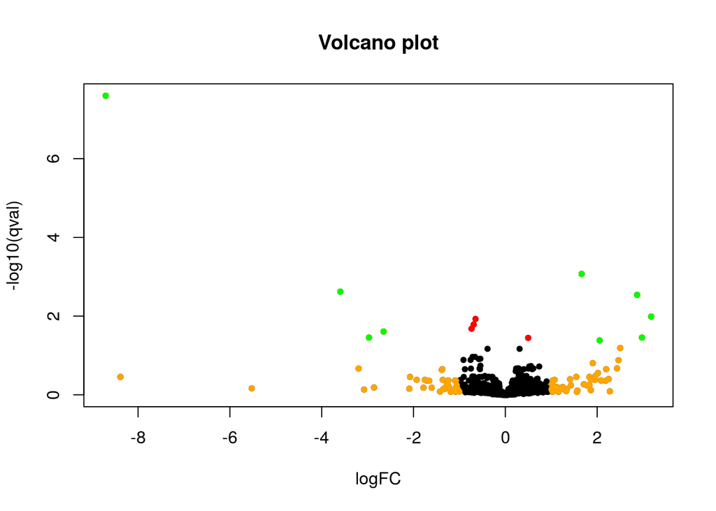

```r
volcano_plot <- function(data){
  logfc.threshold <- 1
  with(data, plot(logFC, -log10(qval), pch=20, main="Volcano plot"))
  with(subset(data, qval<.05 ), points(logFC, -log10(qval), pch=20, col="red"))
  with(subset(data, abs(logFC)>logfc.threshold), points(logFC, -log10(qval), pch=20, col="orange"))
  with(subset(data, qval<.05 & abs(logFC)>logfc.threshold), points(logFC, -log10(qval), pch=20, col="green"))
}

volcano_plot(results_genes)
```

### Distribution

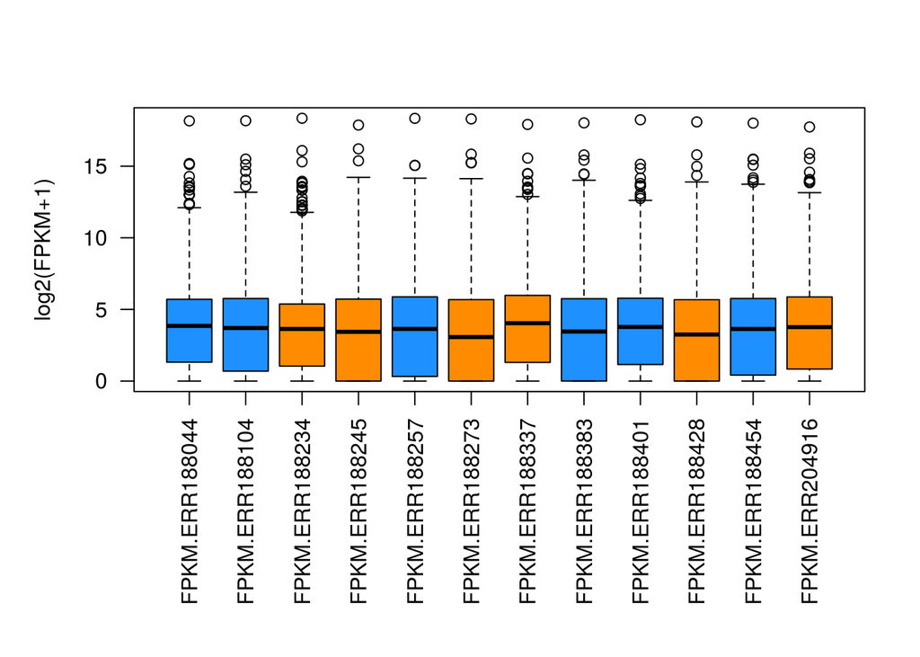

```r
tropical= c('darkorange', 'dodgerblue', 'hotpink', 'limegreen', 'yellow')
palette(tropical)
fpkm = texpr(bg_chrX_filt,meas="FPKM")
fpkm = log2(fpkm+1)
par(mar = c(10,5,4,2) + 0.1)
boxplot(fpkm,col=as.numeric(pheno_data$sex),las=2,ylab='log2(FPKM+1)')
```

### Data variation for one gene

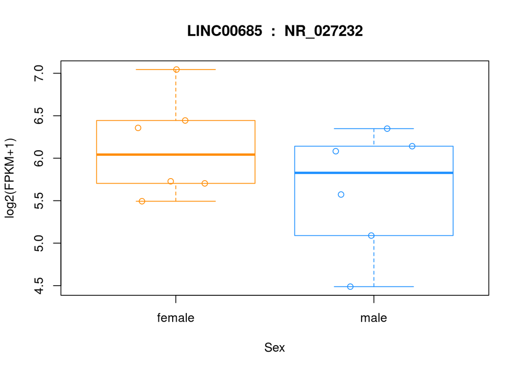

```r
plot(fpkm[12,] ~ pheno_data$sex, border=c(1,2), main=paste(ballgown::geneNames(bg_chrX)[12],' : ', ballgown::transcriptNames(bg_chrX)[12]),pch=19, xlab="Sex", ylab='log2(FPKM+1)')
points(fpkm[12,] ~ jitter(as.numeric(pheno_data$sex)), col=as.numeric(pheno_data$sex))
```

### Plot transcripts

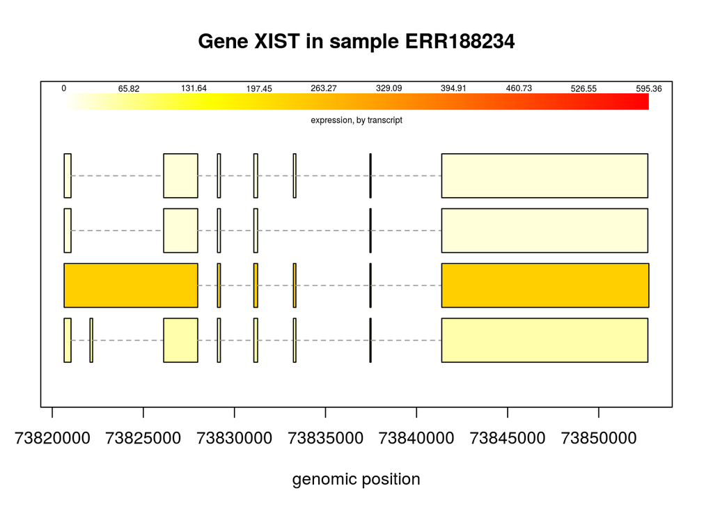

```r
plotTranscripts(ballgown::geneIDs(bg_chrX)[ballgown::geneNames(bg_chrX) == "XIST"], bg_chrX, main=c('Gene XIST in sample ERR188234'), sample=c('ERR188234'))
```

### Heatmap

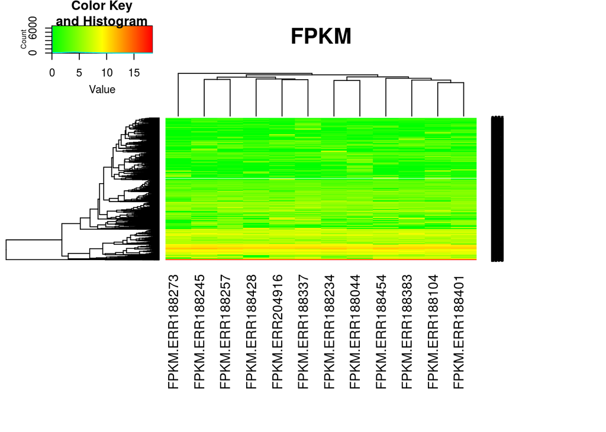

```r
library(RColorBrewer)
library(gplots)
my_palette <- colorRampPalette(c("green", "yellow", "red"))(n = 299)
mat_data <- data.matrix(fpkm)
heatmap.2(mat_data,
  main = "FPKM",
  notecol="black",
  # density.info="none",
  trace="none",
  margins =c(12,9),
  col=my_palette,
  # breaks=col_breaks,
  dendrogram="both")
```

## Export

### Gene expression - FPMK

```r
gene_expression <- gexpr(bg_chrX)
```

|  | FPKM.ERR188044 | FPKM.ERR188104 | FPKM.ERR188234 | FPKM.ERR188245 | FPKM.ERR188257 |
| --- | --- | --- | --- | --- | --- |
| MSTRG.1 | 509.746960 | 319.605100 | 332.294280 | 302.473627 | 178.818228 |
| MSTRG.10 | 21.423500 | 13.129211 | 14.111122 | 18.451681 | 10.181026 |
| MSTRG.100 | 0.470175 | 0.000000 | 0.000000 | 0.361315 | 0.000000 |
| MSTRG.1000 | 6.751377 | 3.257341 | 3.030485 | 2.217741 | 1.993606 |
| MSTRG.1001 | 872.470466 | 682.913294 | 782.223726 | 861.644227 | 774.260158 |

Export to CSV

```r
write.csv(gene_expression, "chrX_gene_expression_results.csv", row.names=FALSE)
```

Export all information in one spreadsheet

```r
write.csv(merge(results_genes, gene_expression, by=0, all=T), "chrX_all_results.csv", row.names=TRUE)
```

### Transcript and genes folds export

```r
write.csv(results_transcripts, "chrX_transcript_results.csv", row.names=FALSE)
write.csv(results_genes, "chrX_gene_results.csv", row.names=FALSE)
```

## Comparison with DESeq2

### DEG computation

The *StringTie* output needs to be converted. It can be done using a python script.

```bash
#This is a shell command
prepDE.py -i ballgown -g stringtie_to_DESeq.genes.csv -t stringtie_to_DESeq.trans.csv -p ERR
```

Then the data can be loaded in DESeq2

```r
library(DESeq2)
counts <- read.csv("stringtie_to_DESeq.genes.csv", row.names = 1)

sex <- as.factor(pheno_data$sex)
pop <- as.factor(pheno_data$population)
ids <- as.vector(pheno_data$ids)

coldata <- data.frame(row.names=ids, pop=pop, sex=sex)

bg_chrX.deseq <- DESeqDataSetFromMatrix(counts, coldata, design=~ sex + pop)
```

The design parameter indicates that there is two variables: *sex* and *pop*. The DEG computation is done using the *DEseq* function.

```r
deseq <- DESeq(bg_chrX.deseq)
deseq.results <- results(deseq)
deseq.results<-deseq.results[order(deseq.results$padj),]
```

As the model varies a lot from *BallGown*. The results are very different. With a small number of replicates (<4?) it is usually advised to use a non-linear model method like DESeq2.

### Volcano plot

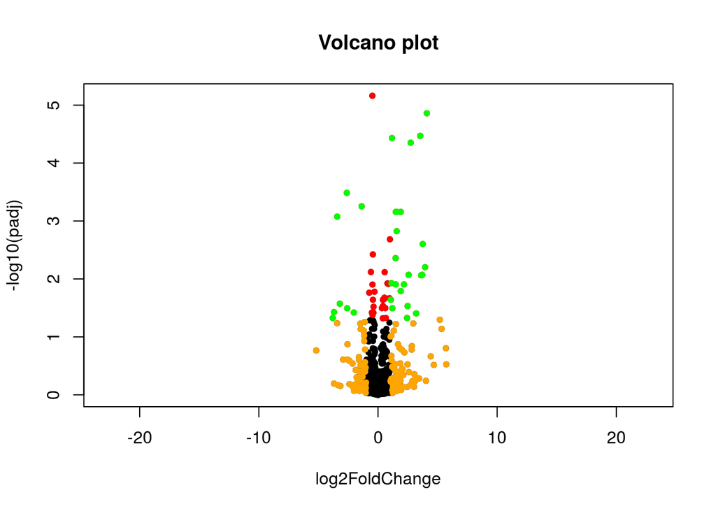

```r
deseq.volcano_plot <- function(data){
  logfc.threshold <- 1
  with(data, plot(log2FoldChange, -log10(padj), pch=20, main="Volcano plot"))
  with(subset(data, padj<.05 ), points(log2FoldChange, -log10(padj), pch=20, col="red"))
  with(subset(data, abs(log2FoldChange)>logfc.threshold), points(log2FoldChange, -log10(padj), pch=20, col="orange"))
  with(subset(data, padj<.05 & abs(log2FoldChange)>logfc.threshold), points(log2FoldChange, -log10(padj), pch=20, col="green"))
}

deseq.volcano_plot(deseq.results)
```

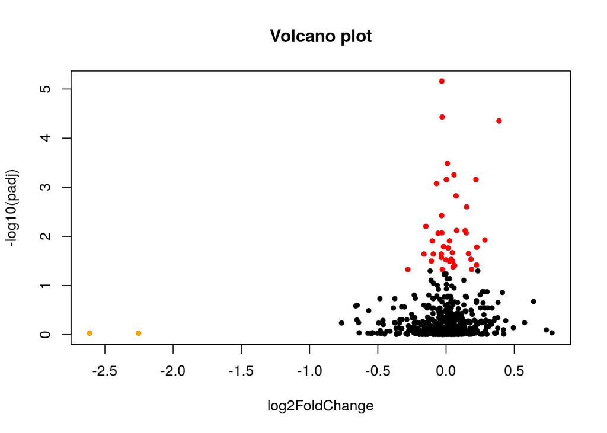

```r
deseq.results.lfcshrink <- lfcShrink(deseq, coef=2, res=deseq.results)
deseq.volcano_plot(deseq.results.lfcshrink)
```

### Venn diagrams comparing both methods

```r
library("VennDiagram")
# dev.off()
logfc.threshold <- 2
BG.genes <- as.vector(subset(results_genes, qval<=.05 & abs(logFC) >= logfc.threshold )$id)
DEseq2.genes <- row.names(subset(deseq.results, padj<=.05 & abs(log2FoldChange) >= logfc.threshold))
venn.list <- list(BG.genes, DEseq2.genes)
venn.plot <- venn.diagram(venn.list,
                          "VennDiagram.png",
                          imagetype = 'png',
                          height = 800,
                          width = 800,
                          resolution = 100,
                          fill=c("darkmagenta", "darkblue"),
                          alpha=c(0.5,0.5),
                          cex = 4,
                          cat.fontface=0.1,
                          category.names=c("BG", "DS2"),
                          main="Differentially expressed genes")
```

This creates a *VennDiagram.png* file:

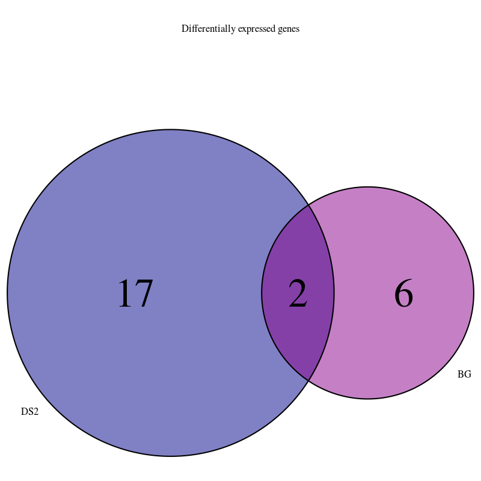

## DEGSeq

```r
library("DEGseq")

file <- file.path(getwd(), "stringtie_to_DESeq.genes.csv")
male.indexes <- as.vector(as.integer(row.names(subset(pheno_data, sex=="male")))+1)
female.indexes <- as.vector(as.integer(row.names(subset(pheno_data, sex=="female")))+1)
deg.geneexp.male <- readGeneExp(file=file, geneCol=1, valCol=male.indexes, header=T, sep=",")
deg.geneexp.female <- readGeneExp(file=file, geneCol=1, valCol=female.indexes, header=T, sep=",")
DEGexp(geneExpMatrix1 = deg.geneexp.male,
       geneExpMatrix2 = deg.geneexp.female,
       geneCol1 = 1,
       expCol1 = c(2,3,4,5,6,7),
       geneCol2 = 1,
       expCol2 = c(2,3,4,5,6,7),
       groupLabel1 = "Male",
       groupLabel2 = "Female",
       method = "LRT",
       outputDir = "DEGseqResults")
```

```r
degseq.result<-read.table(file=file.path("DEGseqResults","output_score.txt"),header = T,sep = "\t")
degseq.result$Signature2 <- (degseq.result$q.value.Storey.et.al..2003. <= 0.05  & abs(degseq.result$log2.Fold_change.) >= 2)
length(which(degseq.result$Signature2=="TRUE"))
```

### Volcano plot:

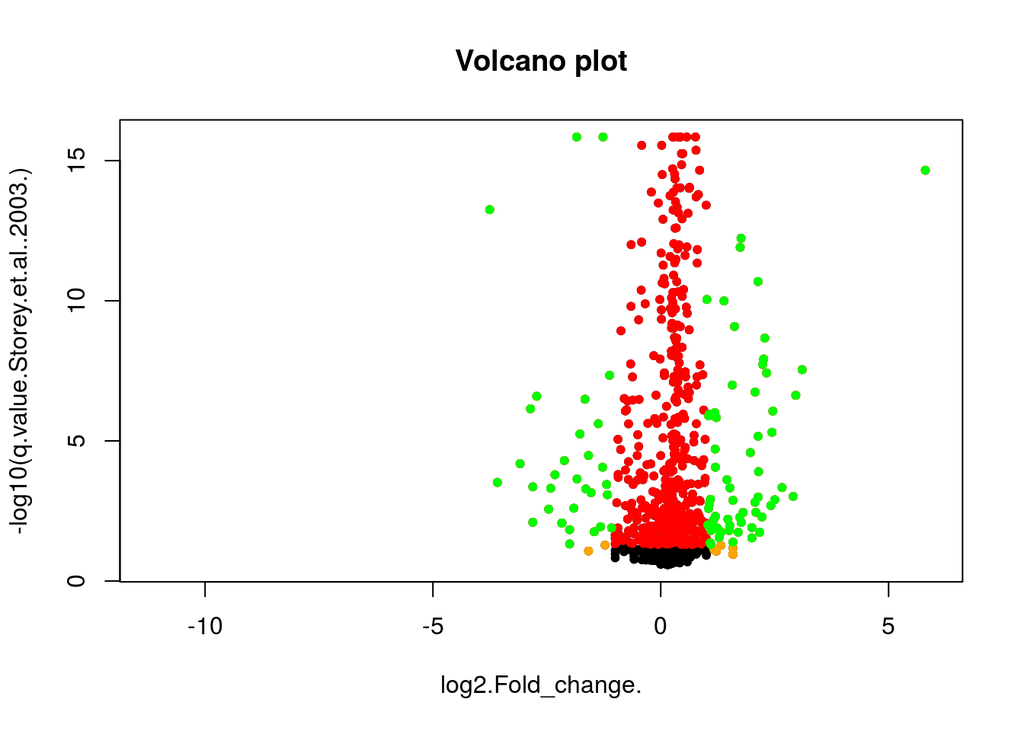

```r
degseq.volcano_plot <- function(data){
  logfc.threshold <- 1
  with(data, plot(log2.Fold_change., -log10(q.value.Storey.et.al..2003.), pch=20, main="Volcano plot"))
  with(subset(data, q.value.Storey.et.al..2003.<.05 ), points(log2.Fold_change., -log10(q.value.Storey.et.al..2003.), pch=20, col="red"))
  with(subset(data, abs(log2.Fold_change.)>logfc.threshold), points(log2.Fold_change., -log10(q.value.Storey.et.al..2003.), pch=20, col="orange"))
  with(subset(data, q.value.Storey.et.al..2003.<.05 & abs(log2.Fold_change.)>logfc.threshold), points(log2.Fold_change., -log10(q.value.Storey.et.al..2003.), pch=20, col="green"))
}

degseq.volcano_plot(degseq.result)
```

### Venn diagram

```r
DEGseq.genes <- as.vector(subset(degseq.result, q.value.Storey.et.al..2003.<=.05 & abs(log2.Fold_change.) >= logfc.threshold )$GeneNames)
venn.list <- list(BG.genes, DEseq2.genes, DEGseq.genes)
venn.plot <- venn.diagram(venn.list,
                          "VennDiagram3.png",
                          imagetype = 'png',
                          height = 800,
                          width = 800,
                          resolution = 100,
                          fill=c("darkmagenta", "darkblue", "darkgreen"),
                          alpha=c(0.5,0.5,0.5),
                          cex = 4,
                          cat.fontface=0.1,
                          category.names=c("BG", "DS2", "DEGseq"),
                          main="Differentially expressed genes")
```

This creates a *VennDiagram3.png* file:

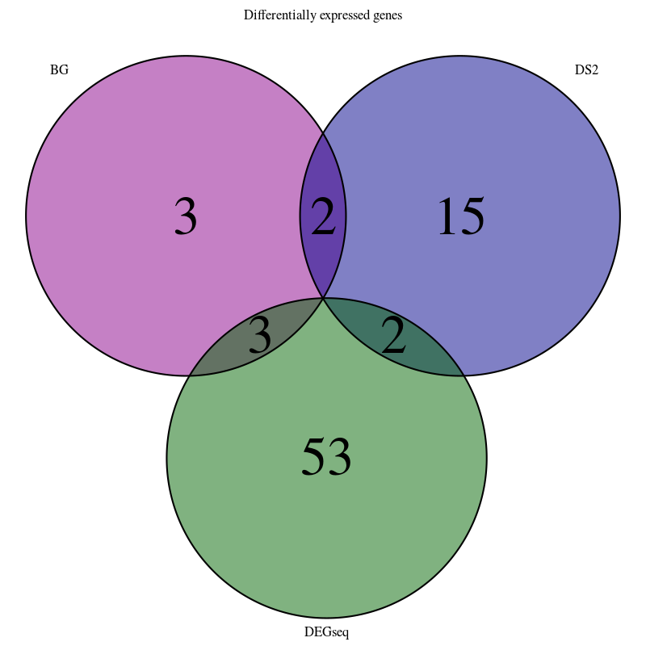

## Final comparison

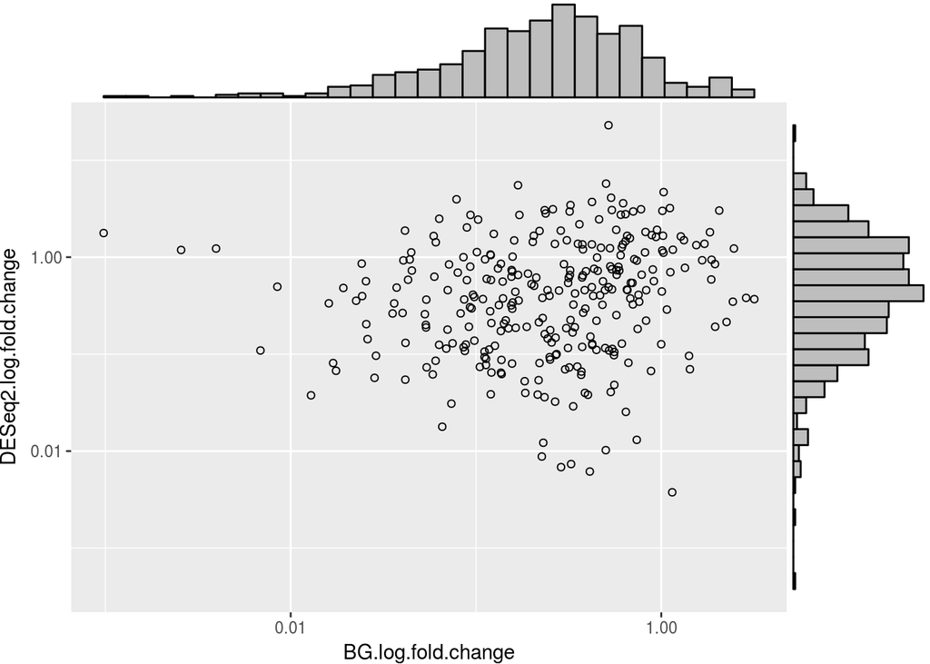

```r
library("ggplot2")
BG.results_genes <- subset(results_genes, select=c("logFC","qval"))
row.names(BG.results_genes) <- results_genes$id
names(BG.results_genes) <- c("BG.log.fold.change","BG.qval")

DEseq2.results_genes <- subset(as.data.frame(deseq.results), select=c("log2FoldChange","padj"))
names(DEseq2.results_genes) <- c("DESeq2.log.fold.change","DESeq2.padj")

dt <- merge(BG.results_genes, DEseq2.results_genes, by=0, all=TRUE)

p <- ggplot(dt, aes(x=BG.log.fold.change, y=DESeq2.log.fold.change)) +
  geom_point(shape=1) +
  scale_y_log10() +
  scale_x_log10()
ggExtra::ggMarginal(p, type="histogram")
```

Here is a comparison of the corrected p-values.

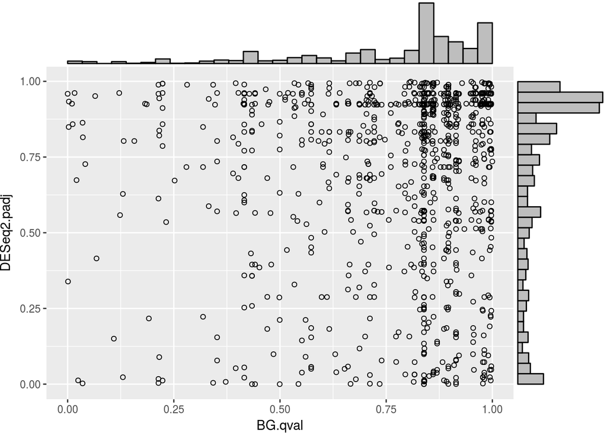

```r
p1 <- ggplot(dt, aes(x=BG.qval, y=DESeq2.padj)) +
  geom_point(shape=1)
ggExtra::ggMarginal(p1, type="histogram")
```